# Hurónske jazero - kompletný model

#### Úloha: Nájdite model pre ČR výšky hladiny Hurónskeho jazera.

#### Znázornenie dát popisujúcich výšku hladiny Hurónskeho jazera, model pre trend a nájdenie reziduí

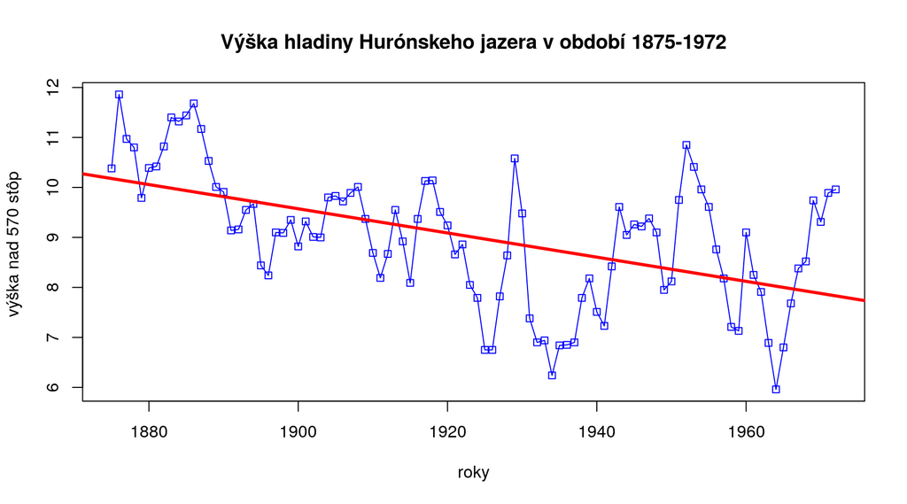

```r
LAKE <- read.table("LAKE.DAT")
lakedata<-LAKE$V1
roky<-1875:1972
plot(roky,lakedata, type = "o", main = "Výška hladiny Hurónskeho jazera v období 1875-1972", ylab="výška nad 570 stôp ", col="blue", pch=22)
trendLake<-lm(lakedata~roky)
abline(trendLake, col="red", lwd=3)
```

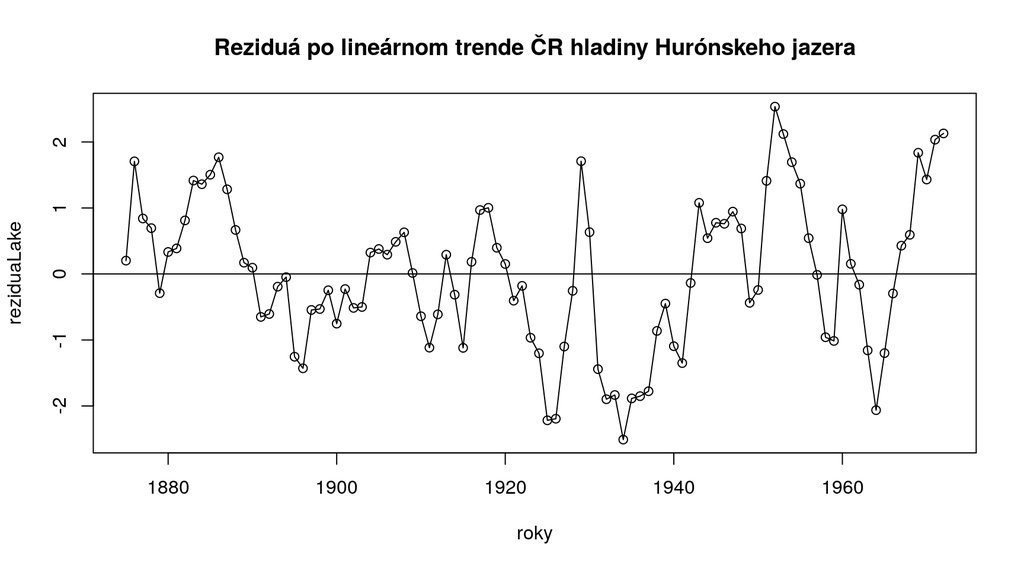

```r
reziduaLake<-residuals(trendLake)
plot(roky,reziduaLake, type="o", main = "Reziduá po lineárnom trende ČR hladiny Hurónskeho jazera")
abline(0,0)
```

#### Úloha: zapíšte čiastočný model ČR

Pri reziduách sme skonštatovali, že ešte nie sú nezávislé, lebo sú čiastočne skorelované a za veľkou hodnotou nebude nasledovať malá. Pozrieme sa na summary():

```r
summary(trendLake)
```

```
##
## Call:
## lm(formula = lakedata ~ roky)
##
## Residuals:
##      Min       1Q   Median       3Q      Max
## -2.50997 -0.72726  0.00083  0.74402  2.53565
##
## Coefficients:
##              Estimate Std. Error t value Pr(>|t|)
## (Intercept) 55.554918   7.764293   7.155 1.66e-10 ***
## roky        -0.024201   0.004036  -5.996 3.55e-08 ***
## ---
## Signif. codes:  0 '***' 0.001 '**' 0.01 '*' 0.05 '.' 0.1 ' ' 1
##
## Residual standard error: 1.13 on 96 degrees of freedom
## Multiple R-squared:  0.2725, Adjusted R-squared:  0.2649
## F-statistic: 35.95 on 1 and 96 DF,  p-value: 3.545e-08
```

Z toho vieme písať čiastočný model ČR:
$$X(t) = 55.55 - 0.024t + Y(t)$$

#### Model pre reziduá

Teraz potrebujeme nájsť model pre reziduá. Bude užitočné nájsť ACF a PACF.

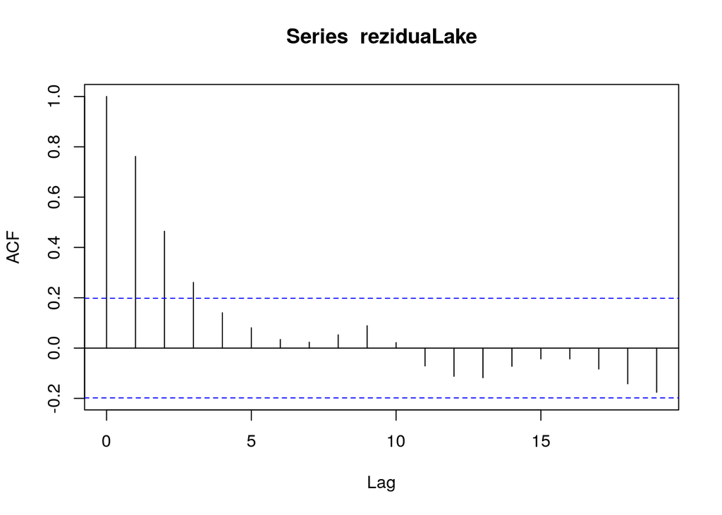

```r
acfLake <- acf(reziduaLake)
```

ACF nám naznačuje, že by to mohol byť MA(2) alebo MA(3) proces.

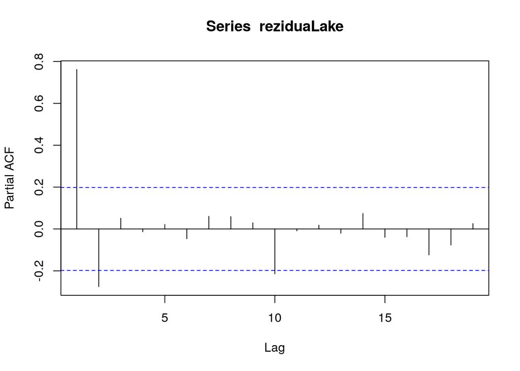

```r
pacfLake <- pacf(reziduaLake)
```

PACF naznačuje možnosť, že by to mohol byť aj AR(1) alebo AR(2).

```r
modelAR2 <- ar.ols(reziduaLake, aic = F, order.max = 2, intercept = F)
modelAR2
```

```
##
## Call:
## ar.ols(x = reziduaLake, aic = F, order.max = 2, intercept = F)
##
## Coefficients:
##       1        2
##  1.0020  -0.2834
##
## Order selected 2  sigma^2 estimated as  0.4436
```

Príkaz nám vráti koeficienty $\phi_1$ a $\phi_2$ ale aj odhad $\sigma$. Ak mu nezadáme order.max, tak sa softvér sám pokúsi ho odhadnúť, častokrát nie veľmi úspešne. Parameter intercept=F spôsobí, že nebudeme mať $\phi_0$.

Poďme sa pozrieť na reziduá modelu.

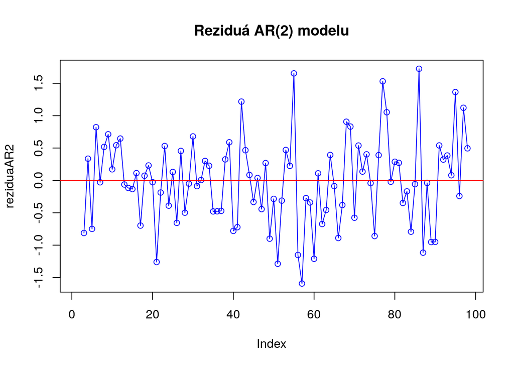

```r
reziduaAR2 <- modelAR2$resid
plot(reziduaAR2, main = 'Reziduá AR(2) modelu', col = 'blue', type = 'o')
abline(0,0, col = 'red')
```

Teraz by už mohli byť aj náhodné… Ale stále ich musíme otestovať! Chýbajú nám prvé dve hodnoty na počítanie - máme rekurzívny vzťah. To je problém pri počítaní.

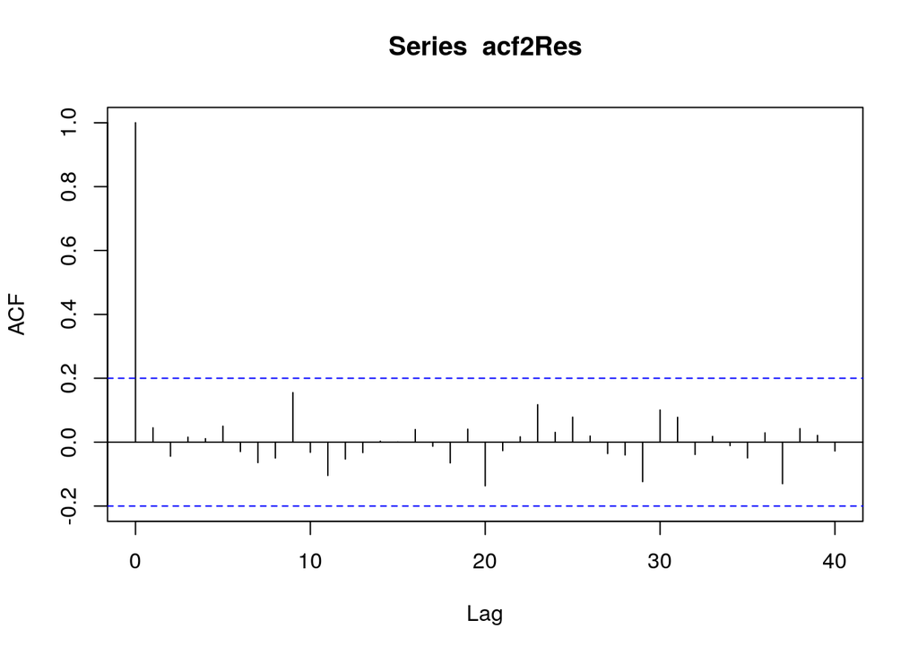

```r
acf2Res <-modelAR2$resid[3:length(reziduaAR2)]
acf(acf2Res, 40)
```

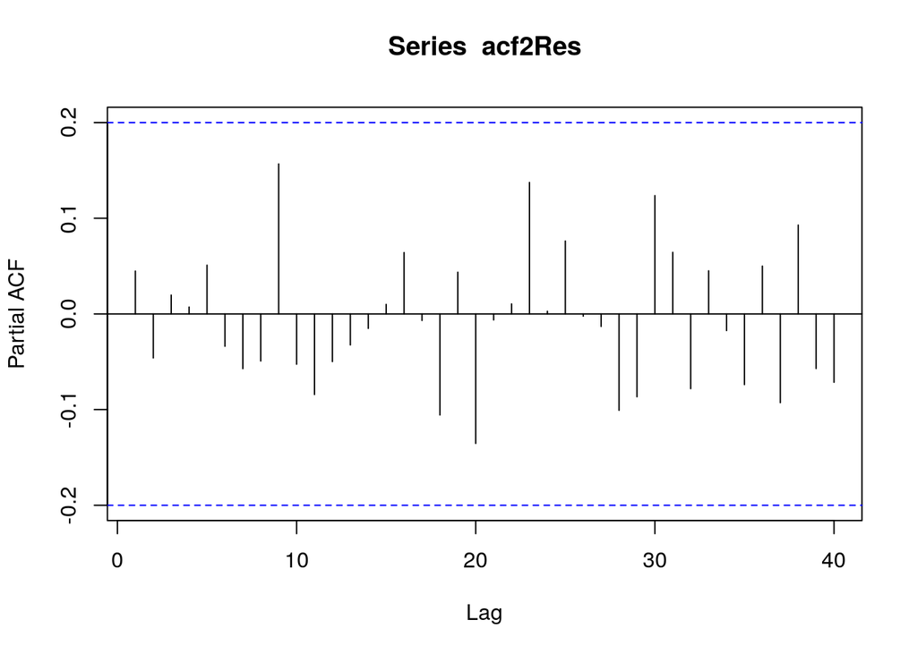

```r
pacf(acf2Res, 40)
```

```r
Box.test(acf2Res)
```

```
##
##  Box-Pierce test
##
## data:  acf2Res
## X-squared = 0.19231, df = 1, p-value = 0.661
```

```r
Box.test(acf2Res, type = 'Ljung')
```

```
##
##  Box-Ljung test
##
## data:  acf2Res
## X-squared = 0.19838, df = 1, p-value = 0.656
```

Teraz to už vyzerá dobre.

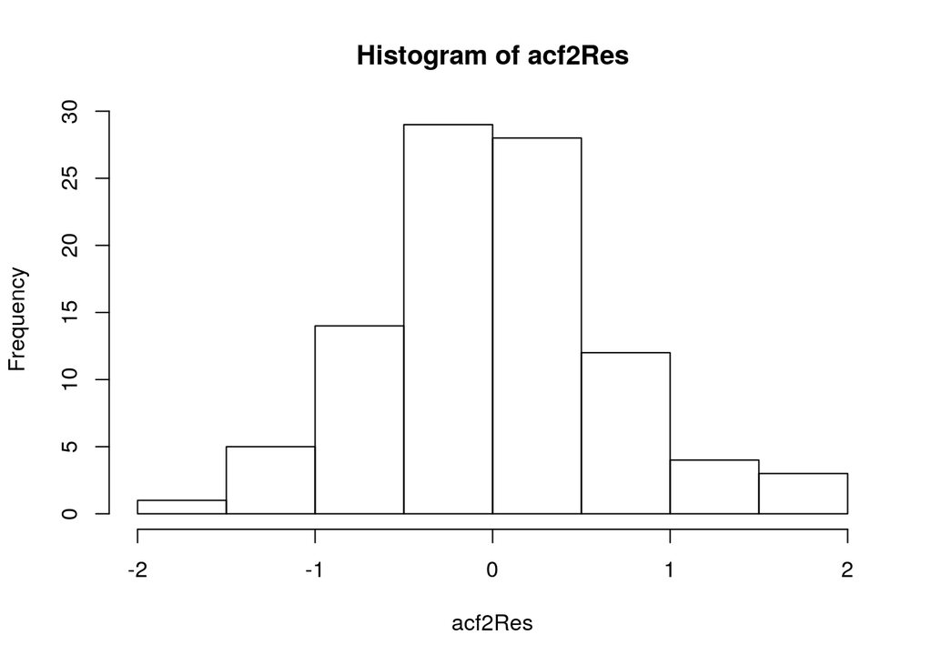

```r
hist(acf2Res)
```

```r
shapiro.test(acf2Res)
```

```
##
##  Shapiro-Wilk normality test
##
## data:  acf2Res
## W = 0.99009, p-value = 0.6981
```

Reziduá sú Gaussovsky rozložené, čo sme chceli.

**Výsledný model:**

$$X(t)=55,55-0,024\cdot t+Y(t)$$
$$Y_t=1,0020Y_{t-1}-0,2834Y_{t-2}+Z_t$$
$$Z_t\sim \mathrm{WN}(0, \sigma^2), \quad \hat{\sigma}^2=0,4436$$